# Analysis of Glucose readings

```matlab
clearvars glucose_row idx_finger idx_serum tbl_serum tbl_finger
```

Missing data removal

```matlab
disp(['Entries before removal of missing data: ',...
    num2str(size(first_readings,1))])
```

Entries before removal of missing data: 12210

```matlab
first_readings = first_readings(~any(ismissing(first_readings,nan),2),:);
disp(['Entries after removal of missing data: ',...
    num2str(size(first_readings,1))])
```

Entries after removal of missing data: 11904

Compute the aritmetic substraction between finger and serum glucose (Δ GLC)

```matlab
% Difference only between glucose readings
d_glc = first_readings.GLC_f_1st-first_readings.GLC_s_1st;
disp(['Mean: ',num2str(mean(d_glc),'%0.2f'),' +/- ',num2str(std(d_glc),'%0.2f')]);
```

Mean: 11.80 +/- 63.59

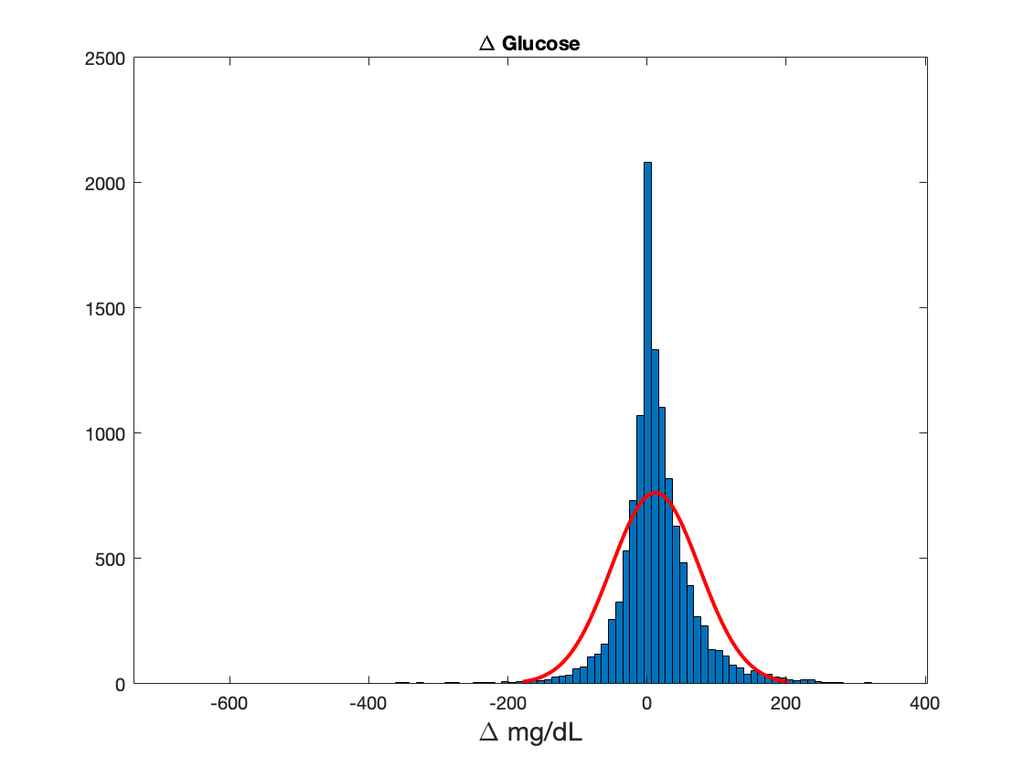

```matlab
figure;
histfit(d_glc)
title('\Delta Glucose')
xlabel('\Delta mg/dL', 'FontSize',14)
```

```matlab
% Mean(Fingerstick - Serum)
d_mean = (first_readings.GLC_f_1st+first_readings.GLC_s_1st)./2;
% (Fingerstick-Serum)/d_mean
d_glc_mean = (first_readings.GLC_f_1st-first_readings.GLC_s_1st)./mean(first_readings.GLC_f_1st+first_readings.GLC_s_1st);
```

Histogram of time gaps between fingerstick and serum glucose

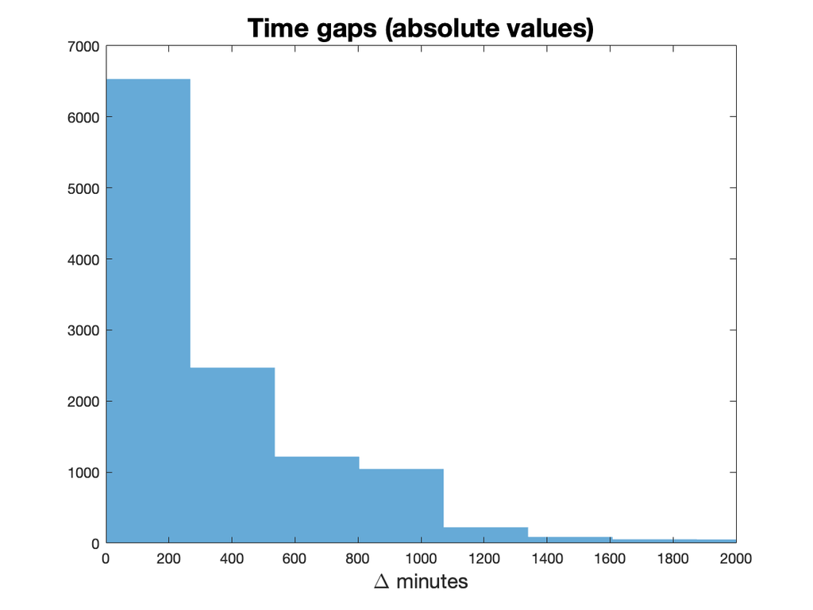

```matlab
histogram(abs(first_readings.time_gap),100,'EdgeAlpha',0);
xlim([0 2000])
title('Time gaps (absolute values)','FontSize',18)
xlabel('\Delta minutes', 'FontSize',14)
```

### Hypothesis testing and Bland Altman analysis

A series of Bland-Altman plots were used to assess the agreement between the two testing types as a function of the time between the tests. The graphs are further complemented with a locally weighted scatter plot smooth (LOWESS) for glucose as the mean of the paired fingerstick-lab analyzed values increases.

Wilcoxon Signed Rank Test

It is a nonparametric test for two populations when the observations are paired. In this case, the test statistic, W, is the sum of the ranks of positive differences between the observations in the two samples (that is, x – y). When you use the test for one sample, then W is the sum of the ranks of positive differences between the observations and the hypothesized median value .

```matlab
theta_array = [30 60 120];

CIdata = nan(5,length(theta_array)+1);

bland = nan(8,length(theta_array)+1);

for i=1:(length(theta_array)+1)
    if i==1
        theta1 = 0;
        theta2 = theta_array(i);
    else
        if i==(length(theta_array)+1)
            theta1 = theta_array(i-1);
            theta2 = max(abs(first_readings.time_gap))+1;
        else
            theta1 = theta_array(i-1);
            theta2 = theta_array(i);
        end
    end
    theta = (abs(first_readings.time_gap)>=theta1)&(abs(first_readings.time_gap)<theta2);

    % Paired Wilcoxon rank test
    % Within +/- theta min
    [p,h,stats] = signrank(d_glc(theta));
    disp('Wilcoxon rank test')
    disp(['[Glucose fingerstick] - [Glucose serum] within ',...
        num2str(theta1),'-',num2str(theta2),' min',newline,...
        'Rejects Ho at the 5% significance level: ', ...
        num2str(h),newline,'p-value = ', num2str(p,'%0.2e'),...
        ', W statistic = ', num2str(stats.signedrank,'%0.2f')])
    disp(['Median: ', num2str(median(d_glc(theta)))]);
    disp(['Q1: ', num2str(quantile(d_glc(theta),0.25)), ...
        newline, ...
        'Q3: ', num2str(quantile(d_glc(theta),0.75)),newline]);
    N = length(d_glc(theta));
    disp(['Entries for ',num2str(theta1),'-',num2str(theta2),' min: ', ...
        num2str(N),newline,...
        num2str((N/(length(d_glc))*100),2),...
        '% of total entries',newline,' '])

    % Compute ‘Standard Error Of The Mean’ Of
    % All Experiments At Each time gap
    ySEM = std(d_glc(theta))/sqrt(N);

    % Calculate 95% Probability Intervals Of
    % t-Distribution
    CI95 = tinv([0.025 0.975], N-1);

    % Calculate 95% Confidence Intervals Of
    % All Experiments At Each time gap
    yCI95 = bsxfun(@times, ySEM, CI95(:));

    % Allocate data
    CIdata(1:2,i) = yCI95;
    % Mean
    CIdata(3,i) = mean(d_glc(theta));
    % SD
    CIdata(4,i) = std(d_glc(theta));
    % N
    CIdata(5,i) = N;

    % Bland Altman analysis
    bland(1,i) = mean(d_glc(theta));
    bland(2,i) = std(d_glc(theta));

    % Limits of agreement
    % Lower
    lower = mean(d_glc(theta))-1.96*(std(d_glc(theta)));
        % SE
    SE = sqrt((3*(lower^2))/(N));
    yCI95 = bsxfun(@times, SE, CI95(:));

    bland(3,i) = lower;
    bland(4:5,i) = yCI95;

    % Upper
    upper = mean(d_glc(theta))+1.96*(std(d_glc(theta)));
        % SE
    SE = sqrt((3*(upper^2))/(N));
    yCI95 = bsxfun(@times, SE, CI95(:));

    bland(6,i) = upper;
    bland(7:8,i) = yCI95;

    clearvars SE lower upper yCI95

    % Title
    if i == (length(theta_array)+1)
        tlt = ['Over ',num2str(theta1), ' min'];
    else
        tlt = [num2str(theta1),' to ',num2str(theta2),' min'];
    end

    subplot(2,2,i)
    hold on
    scatter(d_mean(theta),d_glc(theta),3,'MarkerEdgeColor',[0 0.6 0.6],...
        'MarkerFaceColor',[0 .7 .7],'LineWidth',0.5,...
        'MarkerFaceAlpha',0.5,'MarkerEdgeAlpha',0.5)
    % MEAN
    a = yline(bland(1,i),'-',['MEAN = ',num2str(bland(1,i),'%.1f')],...
        'LineWidth',2.5,'Color',[0.9290 0.6940 0.1250],...
        'LabelVerticalAlignment','middle','FontWeight','bold');
    set(get(get(a,'Annotation'),'LegendInformation'),'IconDisplayStyle','off');
    % SMOOTHING
    tmp_array = [d_mean(theta) d_glc(theta)];
    tmp_array = sortrows(tmp_array,1);
    f = smoothdata(tmp_array(:,2),'lowess',150);
    tmp_array = [tmp_array f];
    plot(tmp_array(:,1),tmp_array(:,3),"LineStyle",'-',...
        "LineWidth",2,"Color",'#7E2F8E');
    % UPPER LIMIT
    b = yline(bland(6,i),'--',['+1.96SD = ',num2str(bland(6,i),'%.1f')],...
        'LineWidth',2,'Color',[0.6350 0.0780 0.1840],...
        'LabelVerticalAlignment','top','FontWeight','bold');
    set(get(get(b,'Annotation'),'LegendInformation'),'IconDisplayStyle','off');
    % LOWER LIMIT
    d = yline(bland(3,i),'--',['-1.96SD = ',num2str(bland(3,i),'%.1f')],...
        'LineWidth',2,'Color',[0.6350 0.0780 0.1840],...
        'LabelVerticalAlignment','bottom','FontWeight','bold');
    set(get(get(d,'Annotation'),'LegendInformation'),'IconDisplayStyle','off');
    hold off
    xlabel('Mean of both tests',"FontSize",16, "FontWeight","bold")
    ylabel('\Delta glucose (mg/dL)', 'FontSize',16, "FontWeight","bold")
    title(tlt,'FontSize',16, "FontWeight","bold")
    xlim([0 max(d_mean)+79])
    ylim([-400 400])
    ax = gca;
    ax.FontSize = 14;

    clearvars a b d h f tmp_array ySEM N ax

end
```

Wilcoxon rank test

[Glucose fingerstick] - [Glucose serum] within 0-30 min Rejects Ho at the 5% significance level: 1 p-value = 2.44e-02, W statistic = 734146.50

Median: 2

Q1: -17 Q3: 21

Entries for 0-30 min: 1683 14% of total entries

Wilcoxon rank test

[Glucose fingerstick] - [Glucose serum] within 30-60 min Rejects Ho at the 5% significance level: 1 p-value = 1.78e-21, W statistic = 236584.00

Median: 4

Q1: -4 Q3: 26

Entries for 30-60 min: 985 8.3% of total entries

Wilcoxon rank test

[Glucose fingerstick] - [Glucose serum] within 60-120 min Rejects Ho at the 5% significance level: 1 p-value = 7.01e-16, W statistic = 447156.50

Median: 0

Q1: -2 Q3: 18

Entries for 60-120 min: 1860 16% of total entries

Wilcoxon rank test

[Glucose fingerstick] - [Glucose serum] within 120-26748 min Rejects Ho at the 5% significance level: 1 p-value = 1.95e-152, W statistic = 18022954.00

Median: 13

Q1: -13 Q3: 44.5

Entries for 120-26748 min: 7376 62% of total entries

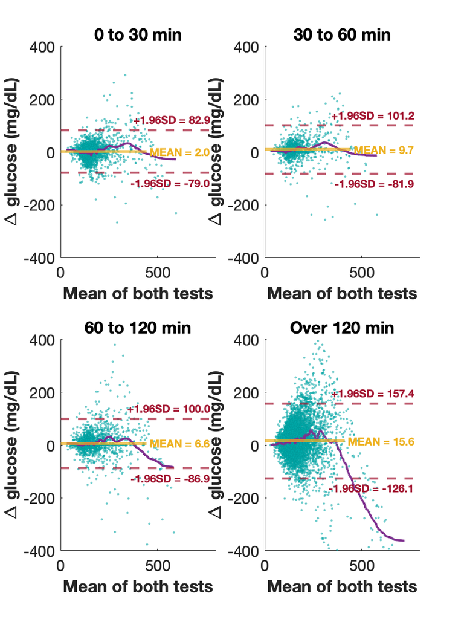

```matlab
fig = gcf;
fig.Units = "centimeters";
fig.Position(3) = 15;
fig.Position(4) = 20;
print(fig,'Bland-Altman','-depsc')
```

## Regression Analysis

We assessed if the frequency of fingerstick vs laboratory tests was associated with any admission, demographic or clinical patient features. A multivariable logistic regression model was fit to identify covariates that with an ICU admission having a higher number of bedside fingerstick readings over samples analyzed in the laboratory. Covariates were patient’s age at admission, ICU admission type, ethnicity, gender, SOFA score, and diabetes condition.

### Import input features ($\textbf{x} = x_1, \dots , x_n$)

Admissions table comes from:

SELECT a.SUBJECT_ID, a.HADM_ID, a.ICUSTAY_ID, a.gender, a.admission_age, a.ethnicity, b.admission_type, a.hospital_expire_flag

FROM `physionet-data.mimiciii_derived.icustay_detail` AS a

LEFT OUTER JOIN (SELECT * FROM

`physionet-data.mimiciii_clinical.admissions`) AS b

ON a.HADM_ID = b.HADM_ID

```matlab
% Import admissions table
admissions = import_admissions("admissions.xlsx", "admissions", [2, 61052]);
disp(['Entries: ', num2str(size(admissions,1))])
```

Entries: 61051

SOFA table comes from:

SELECT ICUSTAY_ID, SOFA

FROM `physionet-data.mimiciii_derived.sofa`

```matlab
% Import SOFA scores
SOFA = import_SOFA("SOFA.xlsx", "SOFA", [2, 61533]);
disp(['Entries: ', num2str(size(SOFA,1))])
```

Entries: 61532

diabetes table comes from:

SELECT a.ICUSTAY_ID, b.DIABETES

FROM `physionet-data.mimiciii_derived.icustay_detail` AS a

LEFT OUTER JOIN (SELECT HADM_ID, diabetes_complicated, diabetes_uncomplicated

, CASE

WHEN diabetes_complicated = 1 THEN 1

WHEN diabetes_uncomplicated = 1 THEN 1

ELSE 0 END AS DIABETES

FROM `physionet-data.mimiciii_derived.elixhauser_quan`) AS b

ON a.HADM_ID = b.HADM_ID

```matlab
% Import diabetes
diabetes = importDiabetes("diabetes.xlsx", "DIABETES", [2, 61052]);
disp(['Entries: ', num2str(size(diabetes,1))])
```

Entries: 61051

```matlab
% Inner join admissions and glucose readings
Tleft = horzcat(first_readings,array2table(d_glc,"VariableNames",{'d_glc'}));
Tright = admissions(:,{'ICUSTAY_ID','admission_age','admission_type','ethnicity',...
    'gender','hospital_expire_flag'});
T = innerjoin(Tleft,Tright,'LeftKeys','ICUSTAY_ID','RightKeys','ICUSTAY_ID');

% Inner join T and SOFA
T = innerjoin(T,SOFA,'LeftKeys','ICUSTAY_ID','RightKeys','ICUSTAY_ID');
% Inner join T and diabetes
T = innerjoin(T,diabetes,'LeftKeys','ICUSTAY_ID','RightKeys','ICUSTAY_ID');
disp(['ICU entries: ', num2str(size(T,1))])
```

ICU entries: 11904

Age at admission

```matlab
% Age at admission
T(T.admission_age>89,'admission_age') = array2table(91.4);
```

Admission type

```matlab
% Admission type
tabulate(categorical(T.admission_type))
```

Value Count Percent ELECTIVE 2257 18.96% EMERGENCY 9504 79.84% NEWBORN 0 0.00% URGENT 143 1.20%

```matlab
T(:,{'admission_type'}) = array2table(mergecats(T.admission_type,...
    {'EMERGENCY','NEWBORN','URGENT'},"EMERGENCY"));
tabulate(categorical(T.admission_type))
```

Value Count Percent ELECTIVE 2257 18.96% EMERGENCY 9647 81.04% NEWBORN 0 0.00% URGENT 0 0.00%

```matlab
T.admission_type = removecats(T.admission_type,...
    {'NEWBORN','URGENT'});
tabulate(T.admission_type)
```

Value Count Percent ELECTIVE 2257 18.96% EMERGENCY 9647 81.04%

Ethnicity

```matlab
% Ethnicity
tabulate(categorical(T.ethnicity))
```

Value Count Percent AMERICAN INDIAN/ALASKA NATIVE 5 0.04% AMERICAN INDIAN/ALASKA NATIVE FEDERALLY RECOGNIZED TRIBE 1 0.01% ASIAN 131 1.10% ASIAN - ASIAN INDIAN 39 0.33% ASIAN - CAMBODIAN 12 0.10% ASIAN - CHINESE 85 0.71% ASIAN - FILIPINO 16 0.13% ASIAN - JAPANESE 2 0.02% ASIAN - KOREAN 6 0.05% ASIAN - OTHER 6 0.05% ASIAN - THAI 0 0.00% ASIAN - VIETNAMESE 15 0.13% BLACK/AFRICAN 9 0.08% BLACK/AFRICAN AMERICAN 1197 10.06% BLACK/CAPE VERDEAN 59 0.50% BLACK/HAITIAN 40 0.34% CARIBBEAN ISLAND 2 0.02% HISPANIC OR LATINO 335 2.81% HISPANIC/LATINO - CENTRAL AMERICAN (OTHER) 6 0.05% HISPANIC/LATINO - COLOMBIAN 2 0.02% HISPANIC/LATINO - CUBAN 11 0.09% HISPANIC/LATINO - DOMINICAN 32 0.27% HISPANIC/LATINO - GUATEMALAN 12 0.10% HISPANIC/LATINO - HONDURAN 0 0.00% HISPANIC/LATINO - MEXICAN 5 0.04% HISPANIC/LATINO - PUERTO RICAN 97 0.81% HISPANIC/LATINO - SALVADORAN 7 0.06% MIDDLE EASTERN 22 0.18% MULTI RACE ETHNICITY 34 0.29% NATIVE HAWAIIAN OR OTHER PACIFIC ISLANDER 1 0.01% OTHER 297 2.49% PATIENT DECLINED TO ANSWER 117 0.98% PORTUGUESE 28 0.24% SOUTH AMERICAN 1 0.01% UNABLE TO OBTAIN 399 3.35% UNKNOWN/NOT SPECIFIED 369 3.10% WHITE 8383 70.42% WHITE - BRAZILIAN 13 0.11% WHITE - EASTERN EUROPEAN 9 0.08% WHITE - OTHER EUROPEAN 29 0.24% WHITE - RUSSIAN 70 0.59%

```matlab
T(:,{'ethnicity'}) = array2table(mergecats(T.ethnicity,{'AMERICAN INDIAN/ALASKA NATIVE',...
    'AMERICAN INDIAN/ALASKA NATIVE FEDERALLY RECOGNIZED TRIBE',...
    'UNKNOWN/NOT SPECIFIED','UNABLE TO OBTAIN','PORTUGUESE','PATIENT DECLINED TO ANSWER',...
    'MULTI RACE ETHNICITY','NATIVE HAWAIIAN OR OTHER PACIFIC ISLANDER','MIDDLE EASTERN',...
    'CARIBBEAN ISLAND'},"OTHER"));
T(:,{'ethnicity'}) = array2table(mergecats(T.ethnicity,{'ASIAN - ASIAN INDIAN',...
    'ASIAN - CAMBODIAN','ASIAN - CHINESE','ASIAN - FILIPINO','ASIAN - JAPANESE',...
    'ASIAN - KOREAN','ASIAN - OTHER','ASIAN - THAI','ASIAN - VIETNAMESE','ASIAN'},...
    "OTHER"));
T(:,{'ethnicity'}) = array2table(mergecats(T.ethnicity,{'WHITE - BRAZILIAN',...
    'WHITE - EASTERN EUROPEAN','WHITE - OTHER EUROPEAN','WHITE - RUSSIAN'},'WHITE'));
T(:,{'ethnicity'}) = array2table(mergecats(T.ethnicity,{'HISPANIC/LATINO - CENTRAL AMERICAN (OTHER)',...
    'HISPANIC/LATINO - COLOMBIAN','HISPANIC/LATINO - CUBAN','HISPANIC/LATINO - DOMINICAN',...
    'HISPANIC/LATINO - GUATEMALAN','HISPANIC/LATINO - HONDURAN','HISPANIC/LATINO - MEXICAN',...
    'HISPANIC/LATINO - PUERTO RICAN','HISPANIC/LATINO - SALVADORAN','HISPANIC OR LATINO',...
    'SOUTH AMERICAN'},"OTHER"));
T(:,{'ethnicity'}) = array2table(mergecats(T.ethnicity,{'BLACK/AFRICAN AMERICAN',...
    'BLACK/CAPE VERDEAN','BLACK/AFRICAN','BLACK/HAITIAN'},"OTHER"));
tabulate(categorical(T.ethnicity))
```

Value Count Percent AMERICAN INDIAN/ALASKA NATIVE 0 0.00% AMERICAN INDIAN/ALASKA NATIVE FEDERALLY RECOGNIZED TRIBE 0 0.00% ASIAN 0 0.00% ASIAN - ASIAN INDIAN 0 0.00% ASIAN - CAMBODIAN 0 0.00% ASIAN - CHINESE 0 0.00% ASIAN - FILIPINO 0 0.00% ASIAN - JAPANESE 0 0.00% ASIAN - KOREAN 0 0.00% ASIAN - OTHER 0 0.00% ASIAN - THAI 0 0.00% ASIAN - VIETNAMESE 0 0.00% BLACK/AFRICAN 0 0.00% BLACK/AFRICAN AMERICAN 0 0.00% BLACK/CAPE VERDEAN 0 0.00% BLACK/HAITIAN 0 0.00% CARIBBEAN ISLAND 0 0.00% HISPANIC OR LATINO 0 0.00% HISPANIC/LATINO - CENTRAL AMERICAN (OTHER) 0 0.00% HISPANIC/LATINO - COLOMBIAN 0 0.00% HISPANIC/LATINO - CUBAN 0 0.00% HISPANIC/LATINO - DOMINICAN 0 0.00% HISPANIC/LATINO - GUATEMALAN 0 0.00% HISPANIC/LATINO - HONDURAN 0 0.00% HISPANIC/LATINO - MEXICAN 0 0.00% HISPANIC/LATINO - PUERTO RICAN 0 0.00% HISPANIC/LATINO - SALVADORAN 0 0.00% MIDDLE EASTERN 0 0.00% MULTI RACE ETHNICITY 0 0.00% NATIVE HAWAIIAN OR OTHER PACIFIC ISLANDER 0 0.00% OTHER 3400 28.56% PATIENT DECLINED TO ANSWER 0 0.00% PORTUGUESE 0 0.00% SOUTH AMERICAN 0 0.00% UNABLE TO OBTAIN 0 0.00% UNKNOWN/NOT SPECIFIED 0 0.00% WHITE 8504 71.44% WHITE - BRAZILIAN 0 0.00% WHITE - EASTERN EUROPEAN 0 0.00% WHITE - OTHER EUROPEAN 0 0.00% WHITE - RUSSIAN 0 0.00%

```matlab
T.ethnicity = removecats(T.ethnicity,...
    {'AMERICAN INDIAN/ALASKA NATIVE',...
    'AMERICAN INDIAN/ALASKA NATIVE FEDERALLY RECOGNIZED TRIBE',...
    'UNKNOWN/NOT SPECIFIED','UNABLE TO OBTAIN','PORTUGUESE',...
    'PATIENT DECLINED TO ANSWER','MULTI RACE ETHNICITY',...
    'NATIVE HAWAIIAN OR OTHER PACIFIC ISLANDER','MIDDLE EASTERN',...
    'CARIBBEAN ISLAND','ASIAN - ASIAN INDIAN',...
    'ASIAN - CAMBODIAN','ASIAN - CHINESE','ASIAN - FILIPINO','ASIAN - JAPANESE',...
    'ASIAN - KOREAN','ASIAN - OTHER','ASIAN - THAI','ASIAN - VIETNAMESE','ASIAN',...
    'WHITE - BRAZILIAN','WHITE - EASTERN EUROPEAN','WHITE - OTHER EUROPEAN',...
    'WHITE - RUSSIAN', 'HISPANIC/LATINO - CENTRAL AMERICAN (OTHER)',...
    'HISPANIC/LATINO - COLOMBIAN','HISPANIC/LATINO - CUBAN','HISPANIC/LATINO - DOMINICAN',...
    'HISPANIC/LATINO - GUATEMALAN','HISPANIC/LATINO - HONDURAN','HISPANIC/LATINO - MEXICAN',...
    'HISPANIC/LATINO - PUERTO RICAN','HISPANIC/LATINO - SALVADORAN','HISPANIC OR LATINO',...
    'BLACK/AFRICAN AMERICAN','BLACK/CAPE VERDEAN','BLACK/AFRICAN','BLACK/HAITIAN','SOUTH AMERICAN'});
tabulate(T.ethnicity)
```

Value Count Percent OTHER 3400 28.56% WHITE 8504 71.44%

## Logistic Regression

Create the output column

```matlab
% Create Binary output class 1 = F > S, otherwise class 0
T(:,'Test_Binary') = array2table(T.count_f > T.count_s);

clearvars idx_geq idx_eq A

tbl = T(:, {'admission_age', 'admission_type', 'ethnicity',...
    'gender', 'hospital_expire_flag', 'SOFA','DIABETES','Test_Binary'});

mdl = fitglm(tbl, 'Distribution', 'binomial', ...
        'link', 'logit', ...
        'CategoricalVars',[false, true, true, true, false, ...
        false, false, false]);
```

#### Odds ratios

```matlab
a = mdl.Coefficients.Estimate;
fprintf(['Intercept     %0.2f\n' ...
    'Age            %0.2f\n' ...
    'Admission type %0.2f\n' ...
    'Ethnicity      %0.2f\n' ...
    'Gender         %0.2f\n' ...
    'Mortality      %0.2f\n' ...
    'SOFA           %0.2f\n' ...
    'Diabetes       %0.2f'],...
    exp(a(1,1)),exp(a(2,1)),exp(a(3,1)),exp(a(4,1)),exp(a(5,1)),...
    exp(a(6,1)),exp(a(7,1)),exp(a(8,1)))
```

Intercept 2.27 Age 1.00 Admission type 0.56 Ethnicity 0.98 Gender 1.15 Mortality 0.53 SOFA 1.01 Diabetes 1.82

```matlab
clearvars a
```

#### p-values

```matlab
p = mdl.Coefficients.pValue;
fprintf(['Intercept     %0.2e\n' ...
    'Age            %0.2e\n' ...
    'Admission type %0.2e\n' ...
    'Ethnicity      %0.3f\n' ...
    'Gender         %0.2e\n' ...
    'Mortality      %0.2e\n' ...
    'SOFA           %0.3f\n' ...
    'Diabetes       %0.2e'],...
    p(1,1),p(2,1),p(3,1),p(4,1),...
    p(5,1),p(6,1),p(7,1),p(8,1))
```

Intercept 8.38e-14 Age 4.02e-03 Admission type 2.03e-23 Ethnicity 0.738 Gender 1.02e-03 Mortality 1.51e-24 SOFA 0.368 Diabetes 1.15e-44

```matlab
clearvars p
```

#### CI

```matlab
% Calculate the 95% confidence limits for the coefficients.
CI_LR = exp(coefCI(mdl));

fprintf(['Intercept      %0.2f to %0.2f\n' ...
    'Age            %0.2f to %0.2f\n' ...
    'Admission type %0.2f to %0.2f\n' ...
    'Ethnicity      %0.2f to %0.2f\n' ...
    'Gender         %0.2f to %0.2f\n' ...
    'Mortality      %0.2f to %0.2f\n' ...
    'SOFA           %0.2f to %0.2f\n' ...
    'Diabetes       %0.2f to %0.2f'],...
    CI_LR(1,1),CI_LR(1,2),...
    CI_LR(2,1),CI_LR(2,2),...
    CI_LR(3,1),CI_LR(3,2),...
    CI_LR(4,1),CI_LR(4,2),...
    CI_LR(5,1),CI_LR(5,2),...
    CI_LR(6,1),CI_LR(6,2),...
    CI_LR(7,1),CI_LR(7,2),...
    CI_LR(8,1),CI_LR(8,2))
```

Intercept 1.83 to 2.82 Age 1.00 to 1.01 Admission type 0.50 to 0.63 Ethnicity 0.90 to 1.08 Gender 1.06 to 1.24 Mortality 0.47 to 0.60 SOFA 0.99 to 1.02 Diabetes 1.67 to 1.98

## Summary of analyzed variables

```matlab
summary(T(:,{'LOS_min', 'admission_age', 'admission_type', 'ethnicity', ...
    'gender', 'hospital_expire_flag', 'SOFA','DIABETES','Test_Binary'}))
```

Variables: **LOS_min**: 11904×1 double Values: Min 0.14395 Median 2.6558 Max 101.74 **admission_age**: 11904×1 double Values: Min 15 Median 66 Max 91.4 **admission_type**: 11904×1 categorical Values: ELECTIVE 2257 EMERGENCY 9647 **ethnicity**: 11904×1 categorical Values: OTHER 3400 WHITE 8504 **gender**: 11904×1 categorical Values: F 4982 M 6922 **hospital_expire_flag**: 11904×1 double Values: Min 0 Median 0 Max 1 **SOFA**: 11904×1 double Values: Min 0 Median 4 Max 21 **DIABETES**: 11904×1 double Values: Min 0 Median 0 Max 1 **Test_Binary**: 11904×1 logical Values: True 8377 False 3527